# Report

Ariel Camacho

11/6/2020

## Data retrieval

```r
library(caret)
```

```r
library(ggplot2)
```

We load the training data:

```r
dataDLA <- read.csv(url("https://d396qusza40orc.cloudfront.net/predmachlearn/pml-training.csv"))
```

Now we explore the data:

```r
dim(dataDLA)
```

```
## [1] 19622   160
```

We have 19622 instances with 160 attributes. We want to predict “classe”. Let’s see how many levels there are:

```r
levels(dataDLA$classe)
```

```
## [1] "A" "B" "C" "D" "E"
```

```r
head(dataDLA)
```

```
##   X user_name raw_timestamp_part_1 raw_timestamp_part_2   cvtd_timestamp
## 1 1  carlitos           1323084231               788290 05/12/2011 11:23
## 2 2  carlitos           1323084231               808298 05/12/2011 11:23
## 3 3  carlitos           1323084231               820366 05/12/2011 11:23
## 4 4  carlitos           1323084232               120339 05/12/2011 11:23
## 5 5  carlitos           1323084232               196328 05/12/2011 11:23
## 6 6  carlitos           1323084232               304277 05/12/2011 11:23
##   new_window num_window roll_belt pitch_belt yaw_belt total_accel_belt
## 1         no         11      1.41       8.07    -94.4                3
## 2         no         11      1.41       8.07    -94.4                3
## 3         no         11      1.42       8.07    -94.4                3
## 4         no         12      1.48       8.05    -94.4                3
## 5         no         12      1.48       8.07    -94.4                3
## 6         no         12      1.45       8.06    -94.4                3
##   kurtosis_roll_belt kurtosis_picth_belt kurtosis_yaw_belt skewness_roll_belt
```

[output cut: 251 more lines]

We observe NA values. Let’s found out the number of NAs in each column:

```r
colSums(is.na(dataDLA))
```

```
##                        X                user_name     raw_timestamp_part_1
##                        0                        0                        0
##     raw_timestamp_part_2           cvtd_timestamp               new_window
##                        0                        0                        0
##               num_window                roll_belt               pitch_belt
##                        0                        0                        0
##                 yaw_belt         total_accel_belt       kurtosis_roll_belt
##                        0                        0                        0
##      kurtosis_picth_belt        kurtosis_yaw_belt       skewness_roll_belt
##                        0                        0                        0
##     skewness_roll_belt.1        skewness_yaw_belt            max_roll_belt
##                        0                        0                    19216
##           max_picth_belt             max_yaw_belt            min_roll_belt
##                    19216                        0                    19216
##           min_pitch_belt             min_yaw_belt      amplitude_roll_belt
##                    19216                        0                    19216
##     amplitude_pitch_belt       amplitude_yaw_belt     var_total_accel_belt
##                    19216                        0                    19216
##            avg_roll_belt         stddev_roll_belt            var_roll_belt
##                    19216                    19216                    19216
##           avg_pitch_belt        stddev_pitch_belt           var_pitch_belt
##                    19216                    19216                    19216
##             avg_yaw_belt          stddev_yaw_belt             var_yaw_belt
##                    19216                    19216                    19216
##             gyros_belt_x             gyros_belt_y             gyros_belt_z
##                        0                        0                        0
##             accel_belt_x             accel_belt_y             accel_belt_z
##                        0                        0                        0
##            magnet_belt_x            magnet_belt_y            magnet_belt_z
##                        0                        0                        0
##                 roll_arm                pitch_arm                  yaw_arm
##                        0                        0                        0
##          total_accel_arm            var_accel_arm             avg_roll_arm
##                        0                    19216                    19216
##          stddev_roll_arm             var_roll_arm            avg_pitch_arm
##                    19216                    19216                    19216
##         stddev_pitch_arm            var_pitch_arm              avg_yaw_arm
##                    19216                    19216                    19216
##           stddev_yaw_arm              var_yaw_arm              gyros_arm_x
##                    19216                    19216                        0
```

[output cut: 53 more lines]

```
##                        0                        0                    19216
##         avg_roll_forearm      stddev_roll_forearm         var_roll_forearm
##                    19216                    19216                    19216
##        avg_pitch_forearm     stddev_pitch_forearm        var_pitch_forearm
##                    19216                    19216                    19216
##          avg_yaw_forearm       stddev_yaw_forearm          var_yaw_forearm
##                    19216                    19216                    19216
##          gyros_forearm_x          gyros_forearm_y          gyros_forearm_z
##                        0                        0                        0
##          accel_forearm_x          accel_forearm_y          accel_forearm_z
##                        0                        0                        0
##         magnet_forearm_x         magnet_forearm_y         magnet_forearm_z
##                        0                        0                        0
##                   classe
##                        0
```

```r
colSums(dataDLA == "")
```

```
##                        X                user_name     raw_timestamp_part_1
##                        0                        0                        0
##     raw_timestamp_part_2           cvtd_timestamp               new_window
##                        0                        0                        0
##               num_window                roll_belt               pitch_belt
##                        0                        0                        0
##                 yaw_belt         total_accel_belt       kurtosis_roll_belt
##                        0                        0                    19216
##      kurtosis_picth_belt        kurtosis_yaw_belt       skewness_roll_belt
##                    19216                    19216                    19216
##     skewness_roll_belt.1        skewness_yaw_belt            max_roll_belt
##                    19216                    19216                       NA
##           max_picth_belt             max_yaw_belt            min_roll_belt
##                       NA                    19216                       NA
##           min_pitch_belt             min_yaw_belt      amplitude_roll_belt
##                       NA                    19216                       NA
##     amplitude_pitch_belt       amplitude_yaw_belt     var_total_accel_belt
##                       NA                    19216                       NA
##            avg_roll_belt         stddev_roll_belt            var_roll_belt
##                       NA                       NA                       NA
##           avg_pitch_belt        stddev_pitch_belt           var_pitch_belt
##                       NA                       NA                       NA
##             avg_yaw_belt          stddev_yaw_belt             var_yaw_belt
##                       NA                       NA                       NA
##             gyros_belt_x             gyros_belt_y             gyros_belt_z
##                        0                        0                        0
##             accel_belt_x             accel_belt_y             accel_belt_z
##                        0                        0                        0
##            magnet_belt_x            magnet_belt_y            magnet_belt_z
##                        0                        0                        0
##                 roll_arm                pitch_arm                  yaw_arm
##                        0                        0                        0
##          total_accel_arm            var_accel_arm             avg_roll_arm
##                        0                       NA                       NA
##          stddev_roll_arm             var_roll_arm            avg_pitch_arm
##                       NA                       NA                       NA
##         stddev_pitch_arm            var_pitch_arm              avg_yaw_arm
##                       NA                       NA                       NA
##           stddev_yaw_arm              var_yaw_arm              gyros_arm_x
##                       NA                       NA                        0
```

[output cut: 53 more lines]

```
##                    19216                        0                       NA
##         avg_roll_forearm      stddev_roll_forearm         var_roll_forearm
##                       NA                       NA                       NA
##        avg_pitch_forearm     stddev_pitch_forearm        var_pitch_forearm
##                       NA                       NA                       NA
##          avg_yaw_forearm       stddev_yaw_forearm          var_yaw_forearm
##                       NA                       NA                       NA
##          gyros_forearm_x          gyros_forearm_y          gyros_forearm_z
##                        0                        0                        0
##          accel_forearm_x          accel_forearm_y          accel_forearm_z
##                        0                        0                        0
##         magnet_forearm_x         magnet_forearm_y         magnet_forearm_z
##                        0                        0                        0
##                   classe
##                        0
```

Observe that from the 19622 instances, we have 19216 instances with NA atttributes such as max_roll_belt. Also, there are empty cells. We drop them out:

```r
dataDLA2 <- dataDLA[colSums(!is.na(dataDLA)) == 19622]
dataDLA2 <- dataDLA2[, colSums(dataDLA2 != "") == 19622 ]
print(head(dataDLA2))
```

```
##   X user_name raw_timestamp_part_1 raw_timestamp_part_2   cvtd_timestamp
## 1 1  carlitos           1323084231               788290 05/12/2011 11:23
## 2 2  carlitos           1323084231               808298 05/12/2011 11:23
## 3 3  carlitos           1323084231               820366 05/12/2011 11:23
## 4 4  carlitos           1323084232               120339 05/12/2011 11:23
## 5 5  carlitos           1323084232               196328 05/12/2011 11:23
## 6 6  carlitos           1323084232               304277 05/12/2011 11:23
##   new_window num_window roll_belt pitch_belt yaw_belt total_accel_belt
## 1         no         11      1.41       8.07    -94.4                3
## 2         no         11      1.41       8.07    -94.4                3
## 3         no         11      1.42       8.07    -94.4                3
## 4         no         12      1.48       8.05    -94.4                3
## 5         no         12      1.48       8.07    -94.4                3
## 6         no         12      1.45       8.06    -94.4                3
##   gyros_belt_x gyros_belt_y gyros_belt_z accel_belt_x accel_belt_y accel_belt_z
```

[output cut: 69 more lines]

```r
print(dim(dataDLA2))
```

```
## [1] 19622    60
```

```r
training <- dataDLA2[, 8:60]
```

## Data exploration

Let’s explore some features to see if we can distinguish relevant attributes.

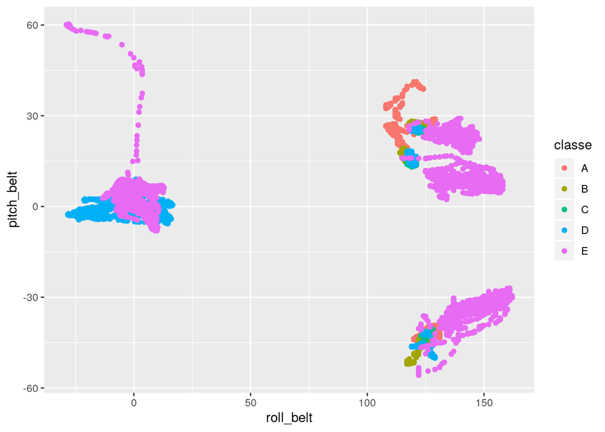

```r
qplot(roll_belt,pitch_belt,data=training,colour=classe)
```

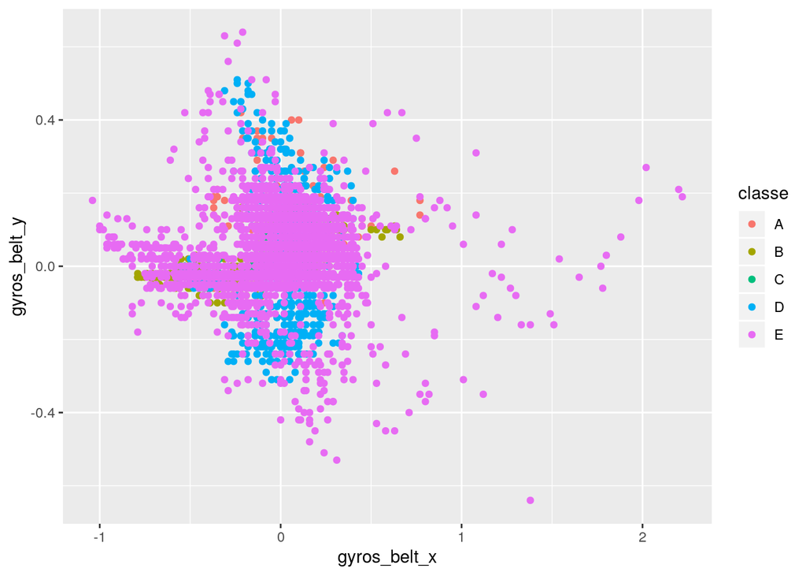

```r
qplot(gyros_belt_x,gyros_belt_y,data=training,colour=classe)
```

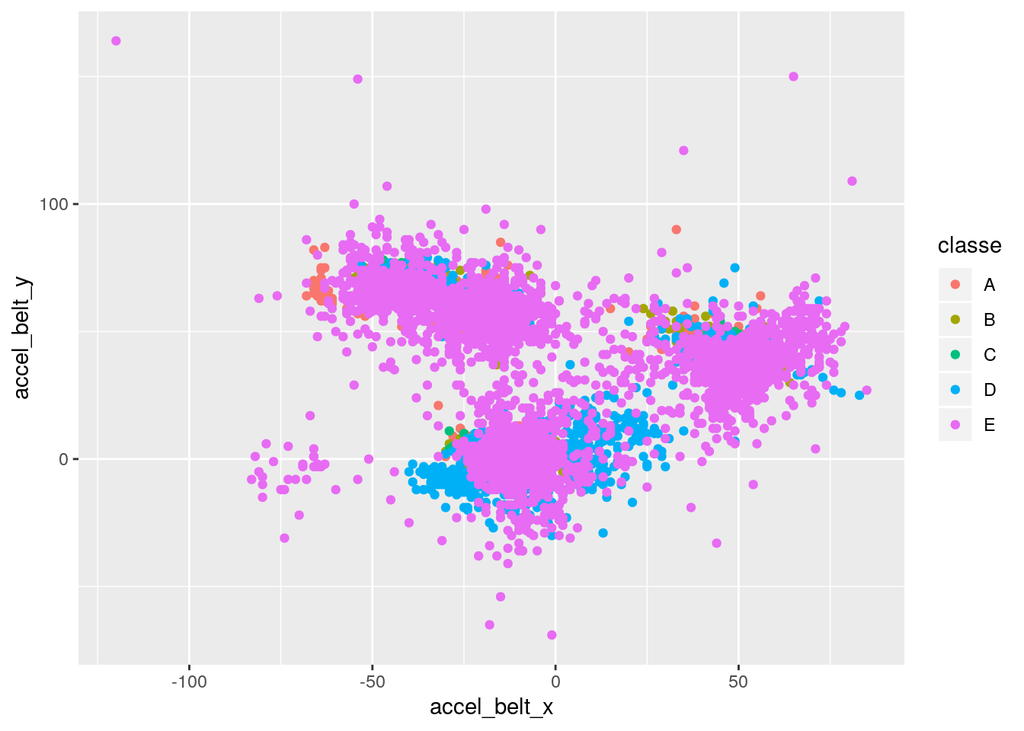

```r
qplot(accel_belt_x,accel_belt_y,data=training,colour=classe)
```

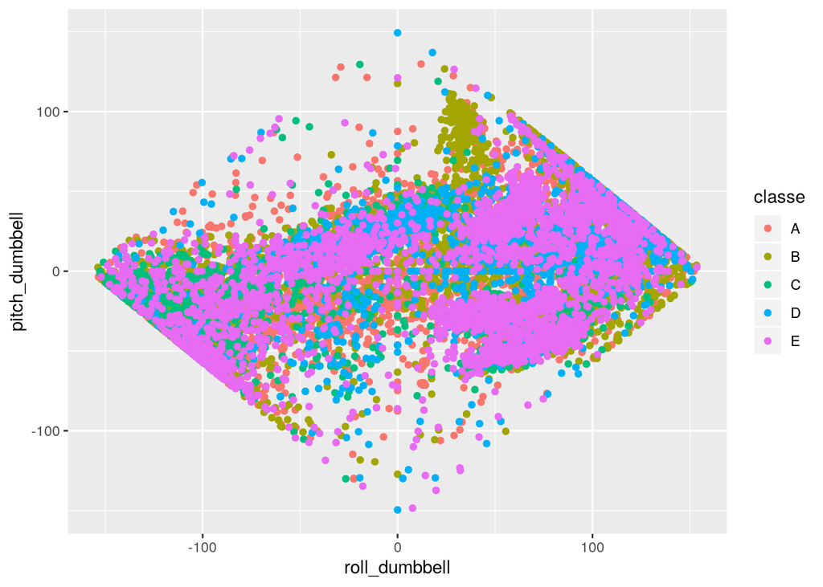

```r
qplot(roll_dumbbell,pitch_dumbbell,data=training,colour=classe)
```

## Fitting models

```r
set.seed(2020)
fitControl <- trainControl(method = "cv", number = 10)
model_lda <- train(classe ~ ., data = training,
                 method = "lda",
                 trControl = fitControl)
model_lda
```

```
## Linear Discriminant Analysis
##
## 19622 samples
##    52 predictor
##     5 classes: 'A', 'B', 'C', 'D', 'E'
##
## No pre-processing
## Resampling: Cross-Validated (10 fold)
## Summary of sample sizes: 17662, 17658, 17660, 17659, 17660, 17660, ...
## Resampling results:
##
##   Accuracy   Kappa
##   0.7024785  0.6234852
```

```r
model_rf <- train(classe ~ ., data = training,
                 method = "rf",
                 trControl = fitControl)
model_rf
```

```
## Random Forest
##
## 19622 samples
##    52 predictor
##     5 classes: 'A', 'B', 'C', 'D', 'E'
##
## No pre-processing
## Resampling: Cross-Validated (10 fold)
## Summary of sample sizes: 17659, 17660, 17661, 17659, 17660, 17660, ...
## Resampling results across tuning parameters:
##
##   mtry  Accuracy   Kappa
##    2    0.9950055  0.9936821
##   27    0.9948527  0.9934886
##   52    0.9898073  0.9871056
##
## Accuracy was used to select the optimal model using the largest value.
## The final value used for the model was mtry = 2.
```

## Testing models

We load the testing data:

```r
library(dplyr)
```

```r
dataDLA_test <- read.csv(url("https://d396qusza40orc.cloudfront.net/predmachlearn/pml-testing.csv"))

columns <- colnames(training)
columns <- columns[-53]
testing <- select(dataDLA_test, columns)
```

```
## Note: Using an external vector in selections is ambiguous.
## ℹ Use `all_of(columns)` instead of `columns` to silence this message.
## ℹ See <https://tidyselect.r-lib.org/reference/faq-external-vector.html>.
```

```r
pred_lda <- predict(model_lda, testing)
pred_lda
```

```
##  [1] B A B C C E D D A A D A B A E A A B B B
## Levels: A B C D E
```

```r
pred_rf <- predict(model_rf, testing)
pred_rf
```

```
##  [1] B A B A A E D B A A B C B A E E A B B B
## Levels: A B C D E
```

```r
postResample(pred_lda, pred_rf)
```

```
##  Accuracy     Kappa
## 0.7000000 0.5890411
```

(Data retrieved from: http://groupware.les.inf.puc-rio.br/har#dataset.)